# slice_sampling_code

AZ

2025-02-23

# Slice Sampling

Slice sampling, introduced by Neal (2003), constructs a Markov chain that explores the target distribution by iteratively defining and sampling from a slice of the density function.

Given a target density $f(x)$, slice sampling introduces an auxiliary variable $y$ such that:

$$S = \{x : y < f(x)\}$$

where $y$ is drawn uniformly from $(0, f(x_0))$, ensuring that $S$ contains the support of the distribution. The sampling process involves:

1. **Evaluate the target function**: Given a target distribution $f(x)$, evaluate $f(x)$ at the current location $x_t$.
2. **Draw a point uniformly**: Draw a point $x_0$ uniformly between $f(x_t)$ and the x-axis.
3. **Create a starting point**: Create a horizontal length $w$ uniformly placed around $x_0$.
4. **Stepping out**: From the starting point, move left and right at length $w$ until the boundaries L and R are above the target function.
5. **Pick a point within the interval**: Choose a point uniformly from [L, R] and check if it is below the target function. If the point is below the function, accept it as a new sample and make this point the new starting point $x_{t+1}$.
6. **Shrinkage**: If the point is not below the target function, shrink the interval and sample again from the updated range.
7. **Repeat**: repeat the shrinkage step until a valid sample is collected.
8. **New start**: make $x_{t+1}$ the new starting point and go back to step 1. Repeat step 1-8 until reaching the desired sample size.

Slice sampling ensures that each sampled point is within the probability region. The stepping out the shrinkage method allows the sampling to be adaptive to the shape of $f(x)$.

Define the target density

```r
# target density
f = function(x) {
  exp(0.4 * (x - 0.4)^2 - 0.08 * x^4)
}
```

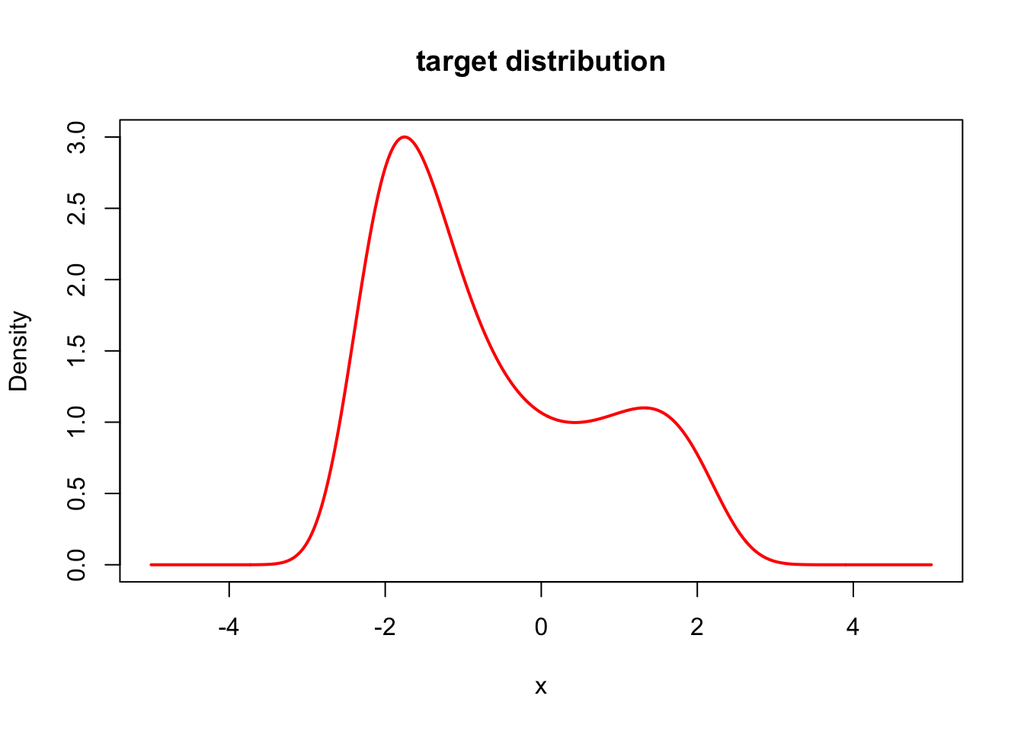

```r
x_vals <- seq(-5, 5, length.out = 1000)
y_vals <- f(x_vals)

plot(x_vals, y_vals, type = "l", col = "red", lwd = 2,
     main = "target distribution",
     xlab = "x", ylab = "Density")
```

initialize sampler

```r
# Set initial values
x0 <- 0  # Starting point
w <- 0.2726316   # Step size for stepping out
n_samples <- 10000  # Number of samples
```

implement slice sampling

```r
set.seed(42)

slice_sample <- function(f, x0, w, n_samples) {
  samples <- numeric(n_samples)  # Storage for samples
  iteration_counts <- numeric(n_samples) #track number of iteration per sample
  total_iterations <-0

  x <- x0  # Initialize x
  start_time <- Sys.time()

  for (i in 1:n_samples) {
    iter_count <- 0 #track iteration for this sample

    # Step 1: Sample auxiliary variable y
    y <- runif(1, 0, f(x))

    # Step 2: Find an interval (L, R) around x using stepping out
    L <- x - w * runif(1)  # Randomly position initial interval
    R <- L + w

    # Expand L and R until they are outside the slice
    while (f(L) > y) { L <- L - w }
    while (f(R) > y) { R <- R + w }

    # Step 3: Sample a new x within (L, R) using shrinkage
    repeat {
      iter_count <- iter_count + 1
      x_new <- runif(1, L, R)  # Sample uniformly from (L, R)
      if (f(x_new) > y) {  # Accept if inside the slice
        x <- x_new
        break
      } else {  # Shrink the interval
        if (x_new < x) { L <- x_new } else { R <- x_new }
      }
    }

    # Store the new sample
    samples[i] <- x
    iteration_counts[i] <- iter_count
    total_iterations <- total_iterations + iter_count
  }
  end_time <- Sys.time()  # End timing
  computing_time <- end_time - start_time

  # Compute average number of iterations
  avg_iterations <- mean(iteration_counts)

  list(
    samples = samples,
    acceptance_rate = n_samples/total_iterations,
    avg_iterations_per_sample = avg_iterations,
    total_iterations = total_iterations,
    total_computing_time = computing_time
  )
}
```

```r
# Run the slice sampling algorithm
res <- slice_sample(f, x0, w, n_samples)

res$acceptance_rate
```

```
## [1] 0.9062897
```

```r
res$avg_iterations_per_sample
```

```
## [1] 1.1034
```

```r
res$total_computing_time
```

```
## Time difference of 0.09900498 secs
```

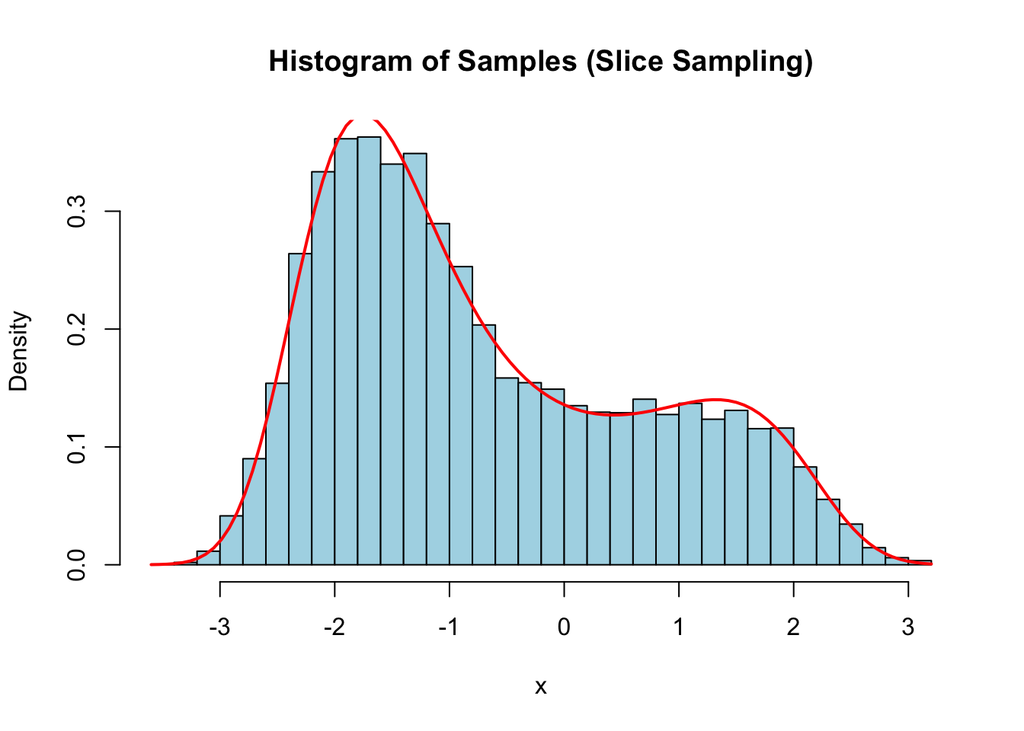

```r
hist(res$samples, probability = TRUE, breaks = 40, col = "lightblue",
     main = "Histogram of Samples (Slice Sampling)",
     xlab = "x", border = "black")

# Define the theoretical density function
f = function(x) {
  exp(0.4 * (x - 0.4)^2 - 0.08 * x^4)
}

# Normalize the density function
x_vals <- seq(-3, 3, length.out = 1000)  # Adjust the range as needed
norm_factor <- integrate(f, -Inf, Inf)$value
norm_f <- function(x) f(x) / norm_factor

# Overlay the normalized density curve
curve(norm_f(x), col = "red", lwd = 2, add = TRUE)
```

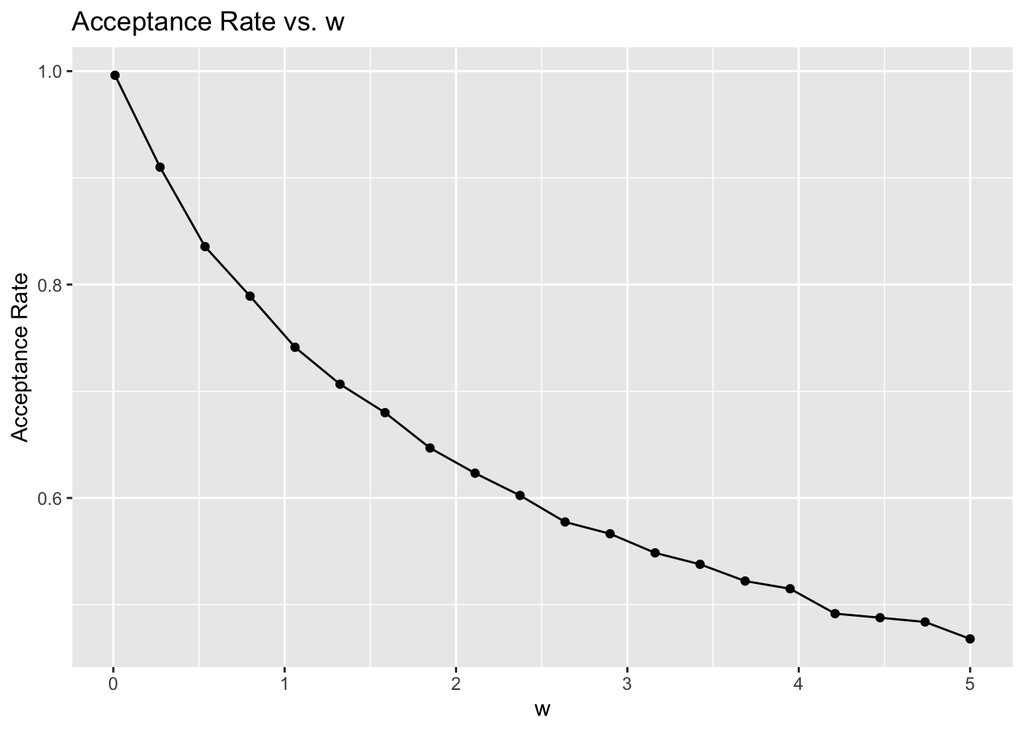

```r
# Define the range of w values
w_values <- seq(0.01, 5, length.out = 20)

# Initialize a data frame to store results
results <- data.frame(w = numeric(),
                      acceptance_rate = numeric(),
                      avg_iterations = numeric(),
                      computing_time = numeric())

# Loop through w values
for (w in w_values) {
  start_time <- Sys.time()  # Start timing
  res <- slice_sample(f, x0, w, n_samples)
  end_time <- Sys.time()    # End timing

  # Store results
  results <- rbind(results, data.frame(
    w = w,
    acceptance_rate = res$acceptance_rate,
    avg_iterations = res$avg_iterations_per_sample,
    computing_time = as.numeric(difftime(end_time, start_time, units = "secs"))
  ))
}

# Load ggplot2 for visualization
library(ggplot2)

# Plot acceptance rate vs. w
ggplot(results, aes(x = w, y = acceptance_rate)) +
  geom_line() + geom_point() +
  labs(title = "Acceptance Rate vs. w", x = "w", y = "Acceptance Rate")
```

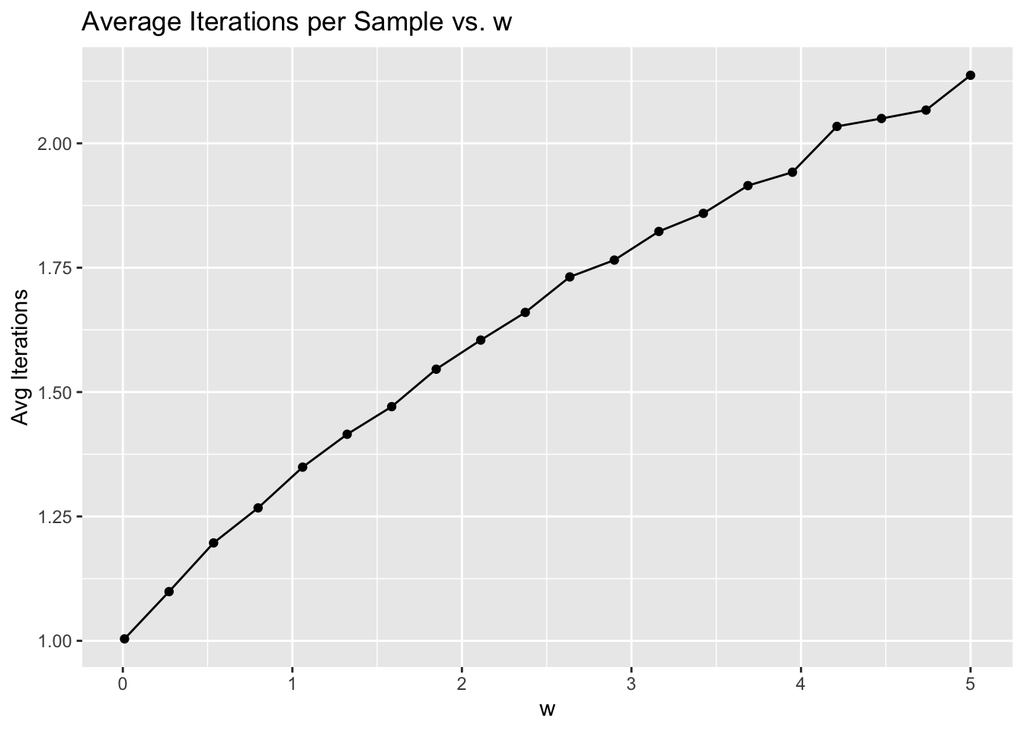

```r
# Plot average iterations per sample vs. w
ggplot(results, aes(x = w, y = avg_iterations)) +
  geom_line() + geom_point() +
  labs(title = "Average Iterations per Sample vs. w", x = "w", y = "Avg Iterations")
```

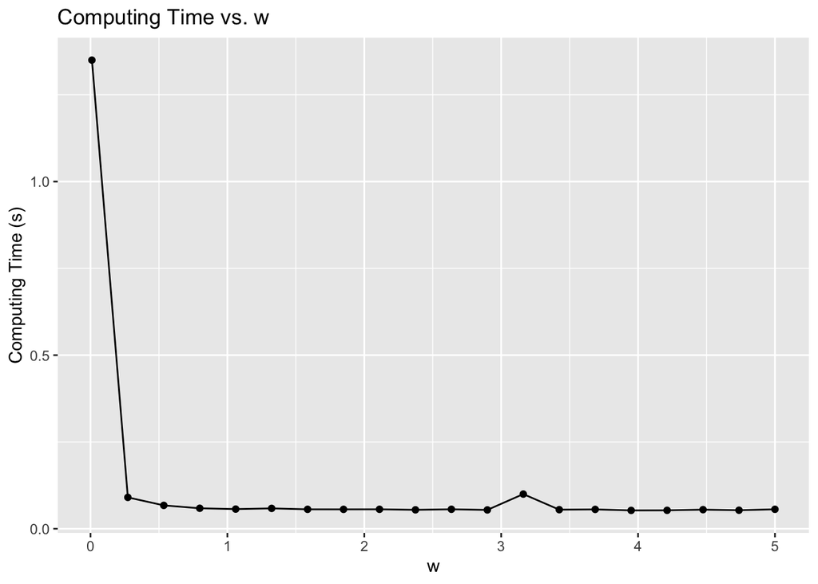

```r
# Plot computing time vs. w
ggplot(results, aes(x = w, y = computing_time)) +
  geom_line() + geom_point() +
  labs(title = "Computing Time vs. w", x = "w", y = "Computing Time (s)")
```

```r
results[1, ]
```

```
##      w acceptance_rate avg_iterations computing_time
## 1 0.01       0.9961152         1.0039       1.349864
```

```r
results[2, ]
```

```
##           w acceptance_rate avg_iterations computing_time
## 2 0.2726316       0.9100009         1.0989     0.09033394
```